# DSCI 303 - Project 04

### Joey Matte

```python
import numpy as np
import pandas as pd
import matplotlib.pyplot as plt
```

## Part 1: Loading the Dataset; Preliminary Analysis

In this section, we will load the data into a DataFrame, and will explore the structure of the data set.

```python
diamonds=pd.read_csv('diamonds.txt', sep='\t')
diamonds.head(10)
```

|  | carat | cut | color | clarity | depth | table | price | x | y | z |
| --- | --- | --- | --- | --- | --- | --- | --- | --- | --- | --- |
| 1 | 0.23 | Ideal | E | SI2 | 61.5 | 55.0 | 326 | 3.95 | 3.98 | 2.43 |
| 2 | 0.21 | Premium | E | SI1 | 59.8 | 61.0 | 326 | 3.89 | 3.84 | 2.31 |
| 3 | 0.23 | Good | E | VS1 | 56.9 | 65.0 | 327 | 4.05 | 4.07 | 2.31 |
| 4 | 0.29 | Premium | I | VS2 | 62.4 | 58.0 | 334 | 4.20 | 4.23 | 2.63 |
| 5 | 0.31 | Good | J | SI2 | 63.3 | 58.0 | 335 | 4.34 | 4.35 | 2.75 |
| 6 | 0.24 | Very Good | J | VVS2 | 62.8 | 57.0 | 336 | 3.94 | 3.96 | 2.48 |
| 7 | 0.24 | Very Good | I | VVS1 | 62.3 | 57.0 | 336 | 3.95 | 3.98 | 2.47 |
| 8 | 0.26 | Very Good | H | SI1 | 61.9 | 55.0 | 337 | 4.07 | 4.11 | 2.53 |
| 9 | 0.22 | Fair | E | VS2 | 65.1 | 61.0 | 337 | 3.87 | 3.78 | 2.49 |
| 10 | 0.23 | Very Good | H | VS1 | 59.4 | 61.0 | 338 | 4.00 | 4.05 | 2.39 |

We will now determiine the size of the dataset.

```python
print(diamonds.shape)
```

```
(53940, 10)
```

We will now inspect the distribution of the columns in diamonds.

```python
diamonds.describe()
```

|  | carat | depth | table | price | x | y | z |
| --- | --- | --- | --- | --- | --- | --- | --- |
| count | 53940.000000 | 53940.000000 | 53940.000000 | 53940.000000 | 53940.000000 | 53940.000000 | 53940.000000 |
| mean | 0.797940 | 61.749405 | 57.457184 | 3932.799722 | 5.731157 | 5.734526 | 3.538734 |
| std | 0.474011 | 1.432621 | 2.234491 | 3989.439738 | 1.121761 | 1.142135 | 0.705699 |
| min | 0.200000 | 43.000000 | 43.000000 | 326.000000 | 0.000000 | 0.000000 | 0.000000 |
| 25% | 0.400000 | 61.000000 | 56.000000 | 950.000000 | 4.710000 | 4.720000 | 2.910000 |
| 50% | 0.700000 | 61.800000 | 57.000000 | 2401.000000 | 5.700000 | 5.710000 | 3.530000 |
| 75% | 1.040000 | 62.500000 | 59.000000 | 5324.250000 | 6.540000 | 6.540000 | 4.040000 |
| max | 5.010000 | 79.000000 | 95.000000 | 18823.000000 | 10.740000 | 58.900000 | 31.800000 |

## Part 2: Filtering and Sorting

```python
diamonds.loc[:,['price','carat','color','clarity']].sort_values(by='carat',ascending=False).head(5)
```

|  | price | carat | color | clarity |
| --- | --- | --- | --- | --- |
| 27416 | 18018 | 5.01 | J | I1 |
| 27631 | 18531 | 4.50 | J | I1 |
| 27131 | 17329 | 4.13 | H | I1 |
| 26000 | 15223 | 4.01 | J | I1 |
| 25999 | 15223 | 4.01 | I | I1 |

```python
diamonds.loc[:,['price','carat','color','clarity']].sort_values(by='price').head(5)
```

|  | price | carat | color | clarity |
| --- | --- | --- | --- | --- |
| 1 | 326 | 0.23 | E | SI2 |
| 2 | 326 | 0.21 | E | SI1 |
| 3 | 327 | 0.23 | E | VS1 |
| 4 | 334 | 0.29 | I | VS2 |
| 5 | 335 | 0.31 | J | SI2 |

We will now view information about the 5 largest diamonds in the dataset with an ideal cut.

```python
diamonds.loc[diamonds['cut']=='Ideal',['price','carat','cut','color','clarity']].sort_values(by='carat',ascending=False).head(5)
```

|  | price | carat | cut | color | clarity |
| --- | --- | --- | --- | --- | --- |
| 24329 | 12587 | 3.50 | Ideal | H | I1 |
| 24298 | 12545 | 3.22 | Ideal | I | I1 |
| 26468 | 16037 | 3.01 | Ideal | J | SI2 |
| 26745 | 16538 | 3.01 | Ideal | J | I1 |
| 24785 | 13156 | 2.75 | Ideal | D | I1 |

```python
diamonds.loc[diamonds['cut']=='Fair',['price','carat','cut','color','clarity']].sort_values(by='carat',ascending=False).head(5)
```

|  | price | carat | cut | color | clarity |
| --- | --- | --- | --- | --- | --- |
| 27416 | 18018 | 5.01 | Fair | J | I1 |
| 27631 | 18531 | 4.50 | Fair | J | I1 |
| 27131 | 17329 | 4.13 | Fair | H | I1 |
| 23645 | 11668 | 3.65 | Fair | H | I1 |
| 26432 | 15964 | 3.40 | Fair | D | I1 |

## Part 3: Working with Categorical Variables

We will now specify the order of the three categorical variables.

```python
clarity_levels=['I1', 'SI2', 'SI1', 'VS2', 'VS1', 'VVS2', 'VVS1', 'IF']
cut_levels=['Fair', 'Good', 'Very Good', 'Premium', 'Ideal']
color_levels=['J', 'I', 'H', 'G', 'F', 'E', 'D']
```

We will now use these lists to communicate to Pandas the correct order for the levels of the three categorical variables.

```python
diamonds.loc[:,'clarity']=pd.Categorical(diamonds.loc[:,'clarity'],clarity_levels)
diamonds.loc[:,'cut']=pd.Categorical(diamonds.loc[:,'cut'],cut_levels)
diamonds.loc[:,'color']=pd.Categorical(diamonds.loc[:,'color'],color_levels)
```

We will now create lists of named colors to serve as palettes to be used for visualizations later in the notebook.

```python
colors=['r','b','g','black','purple','brown','m','y','c']
clarity_pal=colors[:len(clarity_levels)]
cut_pal=colors[:len(cut_levels)]
color_pal=colors[:len(color_levels)]
```

## Part 4: Displaying Counts for Categorical Variables

We will start by counting the number of diamonds for each level of cut.

```python
diamonds.loc[:,'cut'].value_counts().sort_index()
```

```
Fair          1610
Good          4906
Very Good    12082
Premium      13791
Ideal        21551
Name: cut, dtype: int64
```

We will now count the number of diamonds for each level of color.

```python
diamonds.loc[:,'color'].value_counts().sort_index()
```

```
J     2808
I     5422
H     8304
G    11292
F     9542
E     9797
D     6775
Name: color, dtype: int64
```

We will now count the number of diamonds for each level of clarity.

```python
diamonds.loc[:,'clarity'].value_counts().sort_index()
```

```
I1        741
SI2      9194
SI1     13065
VS2     12258
VS1      8171
VVS2     5066
VVS1     3655
IF       1790
Name: clarity, dtype: int64
```

## Part 5: Scatterplots of Price Against Carat

We will explore the relationship between the price and carat attributes by generating scatter plots.

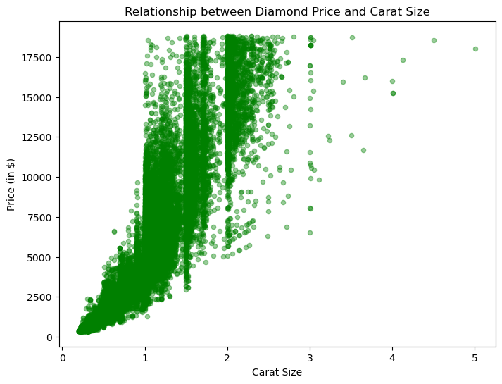

```python
plt.figure(figsize=[8,6])
plt.scatter(diamonds.loc[:,'carat'],diamonds.loc[:,'price'],c='g',s=20,alpha=0.4)
plt.xlabel('Carat Size')
plt.ylabel('Price (in $)')
plt.title('Relationship between Diamond Price and Carat Size')
plt.show()
```

We will reproduce the plot from above, but will now color the points according to their clarity.

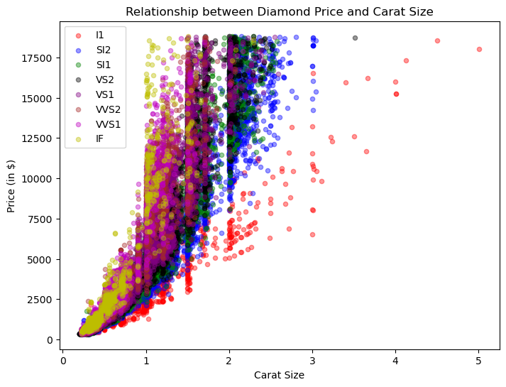

```python
plt.figure(figsize=[8,6])
for i in range(len(clarity_levels)):
    plt.scatter(diamonds.loc[diamonds['clarity']==clarity_levels[i],'carat'],
                diamonds.loc[diamonds['clarity']==clarity_levels[i],'price'],
                c=clarity_pal[i],label=clarity_levels[i],s=20,alpha=0.4)
    plt.xlabel('Carat Size')
    plt.ylabel('Price (in $)')
    plt.title('Relationship between Diamond Price and Carat Size')
    plt.legend()
plt.show()
```

We will now separate the points for each of the eight clarity levels into its own subplot.

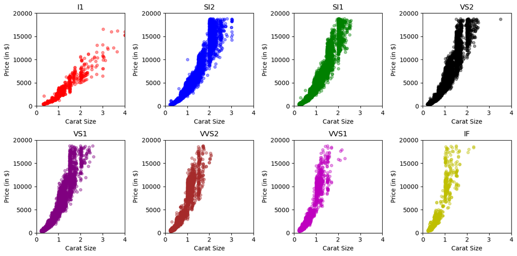

```python
plt.figure(figsize=[12,6])
for i in range(len(clarity_levels)):
    plt.subplot(2,4,i+1)
    plt.scatter(diamonds.loc[diamonds['clarity']==clarity_levels[i],'carat'],
                diamonds.loc[diamonds['clarity']==clarity_levels[i],'price'],
                c=clarity_pal[i],s=20,alpha=0.4)
    plt.xlabel('Carat Size')
    plt.ylabel('Price (in $)')
    plt.title(clarity_levels[i])
    plt.xlim([0,4])
    plt.ylim([0,20000])
plt.tight_layout()
plt.show()
```

## Part 6: Applying Logarithmic Transformations

We will start by adding two new columns to the diamonds in order to store the transformed variables.

```python
diamonds['ln_carat']=np.log(diamonds.loc[:,'carat'])
diamonds['ln_price']=np.log(diamonds.loc[:,'price'])
```

We will now use histograms to explore the distribution of the diamond prices, and the log of the diamond prices.

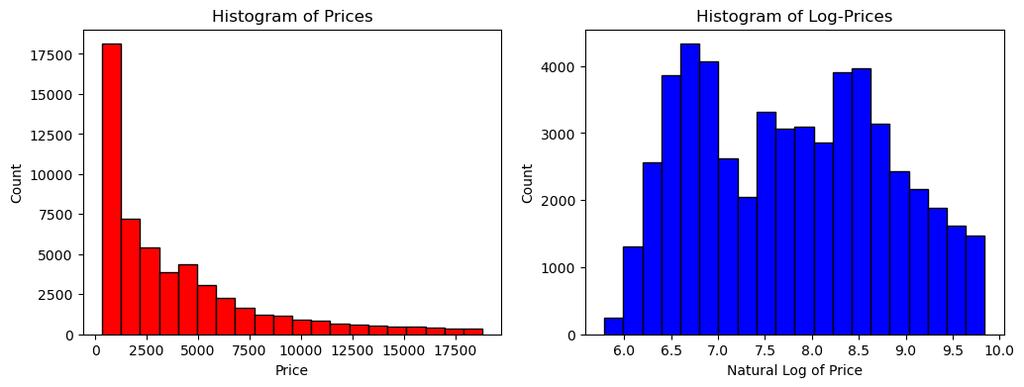

```python
plt.figure(figsize=[12,4])
plt.subplot(1,2,1)
plt.hist(diamonds['price'],bins=20,color='r',edgecolor='k')
plt.xlabel('Price')
plt.ylabel('Count')
plt.title('Histogram of Prices')
plt.subplot(1,2,2)
plt.hist(diamonds['ln_price'],bins=20,color='b',edgecolor='k')
plt.xlabel('Natural Log of Price')
plt.ylabel('Count')
plt.title('Histogram of Log-Prices')
plt.show()
```

We will now use histograms to explore the distribution of the carat sizes, and the log of the carat sizes.

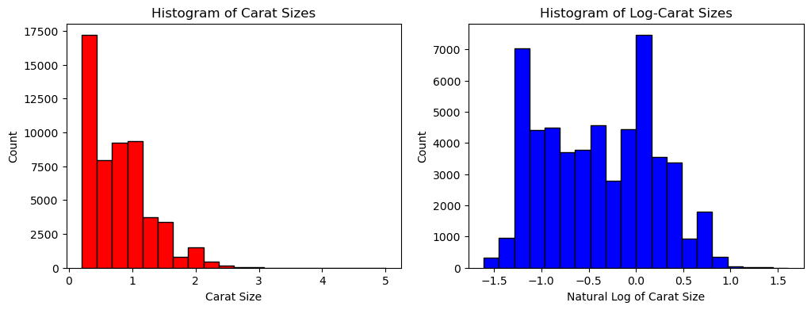

```python
plt.figure(figsize=[12,4])
plt.subplot(1,2,1)
plt.hist(diamonds['carat'],bins=20,color='r',edgecolor='k')
plt.xlabel('Carat Size')
plt.ylabel('Count')
plt.title('Histogram of Carat Sizes')
plt.subplot(1,2,2)
plt.hist(diamonds['ln_carat'],bins=20,color='b',edgecolor='k')
plt.xlabel('Natural Log of Carat Size')
plt.ylabel('Count')
plt.title('Histogram of Log-Carat Sizes')
plt.show()
```

## Part 7: Scatterplot of Transformed Variables

We will create a scatterplot of ln_price against ln_carat, with points colored according to their clarity.

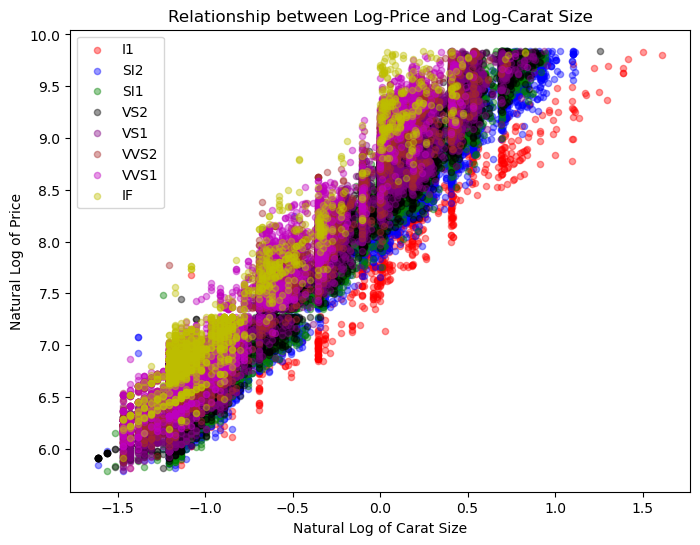

```python
plt.figure(figsize=[8,6])
for i in range(len(clarity_levels)):
    plt.scatter(diamonds.loc[diamonds['clarity']==clarity_levels[i],'ln_carat'],
                diamonds.loc[diamonds['clarity']==clarity_levels[i],'ln_price'],
                c=clarity_pal[i],label=clarity_levels[i],s=20,alpha=0.4)
    plt.xlabel('Natural Log of Carat Size')
    plt.ylabel('Natural Log of Price')
    plt.title('Relationship between Log-Price and Log-Carat Size')
    plt.legend()
plt.show()
```

## Part 8: Grouping by Cut

We will create a grouped DataFrame displaying the mean price and carat size for each cut level.

```python
gb_cut=diamonds.loc[:,['cut','price','carat']].groupby('cut').mean()
gb_cut
```

| cut | price | carat |
| --- | --- | --- |
| Fair | 4358.757764 | 1.046137 |
| Good | 3928.864452 | 0.849185 |
| Very Good | 3981.759891 | 0.806381 |
| Premium | 4584.257704 | 0.891955 |
| Ideal | 3457.541970 | 0.702837 |

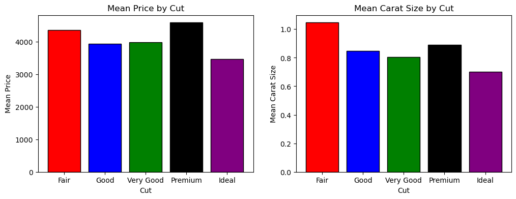

```python
plt.figure(figsize=[12,4])
plt.subplot(1,2,1)
plt.bar(gb_cut.index,gb_cut.iloc[:,0],color=cut_pal,edgecolor='k')
plt.xlabel('Cut')
plt.ylabel('Mean Price')
plt.title('Mean Price by Cut')
plt.subplot(1,2,2)
plt.bar(gb_cut.index,gb_cut.iloc[:,1],color=cut_pal,edgecolor='k')
plt.xlabel('Cut')
plt.ylabel('Mean Carat Size')
plt.title('Mean Carat Size by Cut')
plt.show()
```

## Part 9: Grouping by Color

We will create a grouped DataFrame displaying the mean price and carat size for each color level.

```python
gb_color=diamonds.loc[:,['color','price','carat']].groupby('color').mean()
gb_color
```

| color | price | carat |
| --- | --- | --- |
| J | 5323.818020 | 1.162137 |
| I | 5091.874954 | 1.026927 |
| H | 4486.669196 | 0.911799 |
| G | 3999.135671 | 0.771190 |
| F | 3724.886397 | 0.736538 |
| E | 3076.752475 | 0.657867 |
| D | 3169.954096 | 0.657795 |

We will now use bar charts to graphically display the information from the DataFrame above.

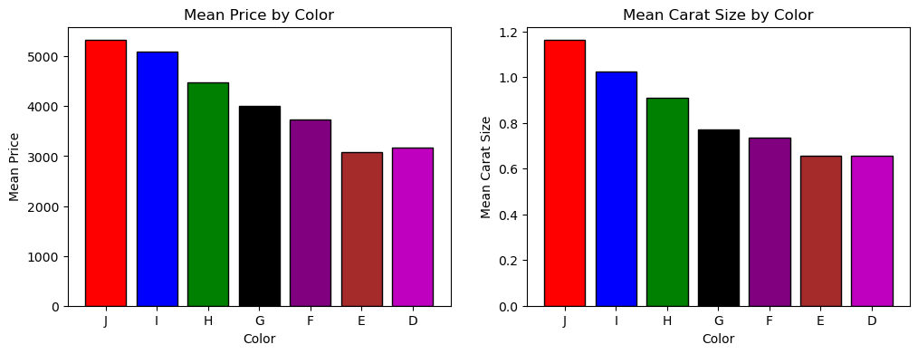

```python
plt.figure(figsize=[12,4])
plt.subplot(1,2,1)
plt.bar(gb_color.index,gb_color.iloc[:,0],color=color_pal,edgecolor='k')
plt.xlabel('Color')
plt.ylabel('Mean Price')
plt.title('Mean Price by Color')
plt.subplot(1,2,2)
plt.bar(gb_color.index,gb_color.iloc[:,1],color=color_pal,edgecolor='k')
plt.xlabel('Color')
plt.ylabel('Mean Carat Size')
plt.title('Mean Carat Size by Color')
plt.show()
```

## Part 10: Grouping by Clarity

We will create a grouped DataFrame displaying the mean price and carat size for each clarity level.

```python
gb_clarity=diamonds.loc[:,['clarity','price','carat']].groupby('clarity').mean()
gb_clarity
```

| clarity | price | carat |
| --- | --- | --- |
| I1 | 3924.168691 | 1.283846 |
| SI2 | 5063.028606 | 1.077648 |
| SI1 | 3996.001148 | 0.850482 |
| VS2 | 3924.989395 | 0.763935 |
| VS1 | 3839.455391 | 0.727158 |
| VVS2 | 3283.737071 | 0.596202 |
| VVS1 | 2523.114637 | 0.503321 |
| IF | 2864.839106 | 0.505123 |

We will now use bar charts to graphically display the information from the DataFrame above.

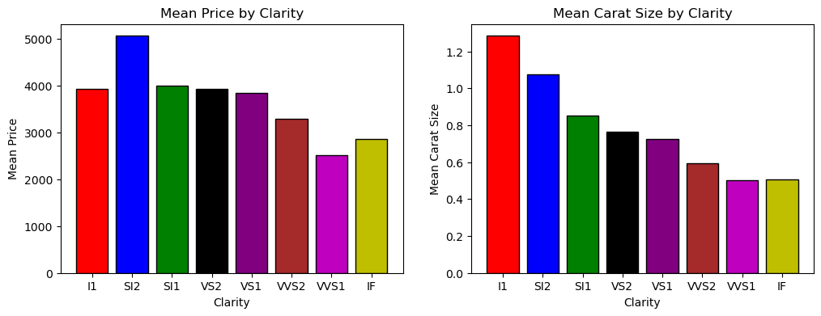

```python
plt.figure(figsize=[12,4])
plt.subplot(1,2,1)
plt.bar(gb_clarity.index,gb_clarity.iloc[:,0],color=clarity_pal,edgecolor='k')
plt.xlabel('Clarity')
plt.ylabel('Mean Price')
plt.title('Mean Price by Clarity')
plt.subplot(1,2,2)
plt.bar(gb_clarity.index,gb_clarity.iloc[:,1],color=clarity_pal,edgecolor='k')
plt.xlabel('Clarity')
plt.ylabel('Mean Carat Size')
plt.title('Mean Carat Size by Clarity')
plt.show()
```